# Survival Theory Course – Spring 2021

Frailty

Mark Clements

# Outline

1. Multiplicative frailty
2. Collapsibility
3. Multivariate frailty models
4. Regularity conditions (if we have time)

# Review and motivation for the analytical approach

- From Andrea's lecture, we used counting processes to show that parametric survival models enjoy the usual properties for maximum likelihood estimation (assuming the model satisfies certain regularity properties:).
- For most of chapters 6 and 7 of ABG on frailties, the authors assume parametric models, as this considerably simplifies the development. I will follow the authors' approach.
- For an example of counting processes for frailty models, see Nielsen et al (Scandinavian Journal of Statistics, 1992;19:25–43).

# § 6: Multiplicative frailty

- ABG: Assume that the hazard rate of an individual is given as the product of an individual specific quantity $Z$ and a basic rate $\alpha(t)$, such that

$$\begin{align*}
\alpha(t|Z) &= Z\alpha(t)
\end{align*}$$

- Note that $Z$ and $\alpha(t)$ are *not* observable. What may be observed in a population is not the individual hazard rates, but the net results for a number of individuals with differing frailties, or what we term the population hazard rate.

# Population hazard

- Given $Z$, survival to time $t$ is given by

$$\begin{align*}
S(t|Z) &= \exp\left(-Z\int_0^t \alpha(u) du\right) \\
&= \exp(-Z A(t))
\end{align*}$$

where $A(t)$ is the cumulative hazard. As from earlier in the course, $A(t)$ plays an important role in the mathematical development.

- The population survival function is found by integrating over the distribution of $Z$, such that

$$\begin{align*}
S(t) &= \int_0^\infty f_Z(z) e^{-zA(t)} dz = E_Z\left(e^{-ZA(t)}\right)
\end{align*}$$

# Laplace transform

- It is very useful to introduce the Laplace transform of $Z$, defined by

$$\begin{align*}
\mathcal{L}(c) &= E_Z\left(e^{-cZ}\right)
\end{align*}$$

and to write

$$\begin{align*}
S(t) &= \mathcal{L}(A(t))
\end{align*}$$

- The population hazard rate, denoted by $\mu(t)$, may be found by differentiating $-\log(S(t))$, so that

$$\begin{align*}
\mu(t) &= \alpha(t)\frac{-\mathcal{L}'(A(t))}{\mathcal{L}(A(t))}
\end{align*}$$

- Hence the difference between the individual hazard rate and the population hazard rate is the ratio $-\mathcal{L}'(A(t))/\mathcal{L}(A(t))$. This factor can be shown to always be a decreasing function.

# Laplace transform

- Also consider the Laplace transform of the frailty distribution for survivors at time $t$, such that

$$\begin{align*}
\mathcal{L}_t(c) &= E_Z\left(e^{-cZ}|T>t\right) = \frac{E\left(e^{-cZ}I(T>t)\right)}{P(T>t)} \\
&= \frac{E\left(e^{-cZ-ZA(t)}\right)}{E\left(e^{-ZA(t)}\right)} \\
&= \frac{\mathcal{L}(c+A(t))}{\mathcal{L}(A(t))}
\end{align*}$$

- This is relevant for considering both left truncation and the change in the frailty distribution conditional on survival to a point in time.

# Notes

1. The distribution of $Z$ is an example of a mixing distribution. Mixing models are used in a number of different contexts. What are other examples of mixing distributions?
2. The proportional frailty model is chosen for mathematical convenience. It represents a specific simplified view of how individual heterogeneity might act. There is no reason why heterogeneity should be determined at time zero, that it should be constant over time, or that it should act in a proportional manner.
3. Nevertheless, the model is useful for illustrating a number of issues concerning heterogeneity – hence the cool name of Chapter 6: "Unobserved heterogeneity: The odd effects of frailty".

# Gamma frailty distribution

- Frailty distributions are often selected due to their tractable Laplace transform.
- A common choice is the gamma distribution, which has a probability density function

$$\begin{align*}
f_Z(z) &= \frac{\nu^\eta}{\Gamma(\eta)z^{\eta-1}\exp(\nu z)}
\end{align*}$$

where $\Gamma(\eta)=\displaystyle\int_0^\infty \displaystyle\frac{1}{z^{1-\eta}\exp(z)}dz$, $\nu$ is a `scale` parameter, and $\eta$ is a `shape` parameter.

- $E(Z)=\eta/\nu$ and $\text{var}(Z)=\eta/\nu^2$
- Confusingly, R's `[dpqr]gamma` functions define the “scale” as $\nu^{-1}$ and call $\nu$ the “rate”.

# Gamma frailty distribution

- It is often natural to let the frailty distribution $Z$ have mean equal to 1, so that $\eta=\nu$, which has $\text{var}(Z)=\nu^{-1}$. We now parameterise the distribution using the variance $\delta=\nu^{-1}$. R code:

```r
library(dplyr)
```

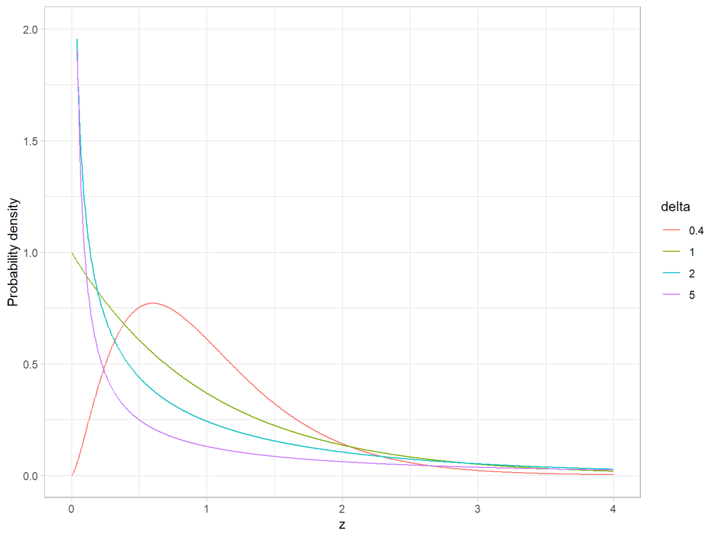

```r
library(ggplot2)
expand.grid(z = seq(0,4,length=1001),
            delta = c(0.4,1,2,5)) %>%
    mutate(y=stats::dgamma(z, shape=1/delta, scale=delta),
           delta=factor(delta)) %>%
    ggplot(aes(x=z, y=y, col=delta)) + geom_line() +
    ylim(0,2) + xlab("z") +
    ylab("Probability density") + theme_light()
```

# Gamma frailty distribution

- The Laplace transform is then given as

$$\begin{align*}
\mathcal{L}(c) &= (1+\delta c)^{-1/\delta}
\end{align*}$$

- We can now express the population survival as

$$\begin{align*}
S(t) &= \mathcal{L}(A(t)) = (1+\delta A(t))^{-1/\delta}
\end{align*}$$

and the population hazard rate as

$$\begin{align*}
\mu(t) &= -\frac{\mathcal{L}'(A(t))}{\mathcal{L}(A(t))} = \frac{\alpha(t)}{1+\delta A(t)}
\end{align*}$$

# Gamma frailty: population hazard rate $(\alpha(t)=1)$

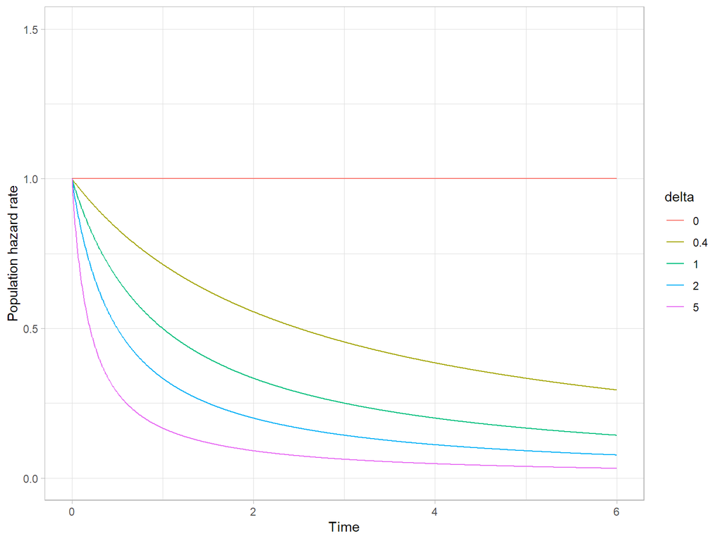

```r
expand.grid(t = seq(0,6,length=1001),
            delta = c(0, 0.4,1,2,5)) %>%
    mutate(alpha = 1,
           A = alpha*t,
           mu = alpha/(1+delta*A),
           delta=factor(delta)) %>%
    ggplot(aes(x=t, y=mu, col=delta)) + geom_line() +
    ylim(0,1.5) + xlab("Time") +
    ylab("Population hazard rate") + theme_light()
```

# Gamma frailty: population survival $(\alpha(t)=1)$

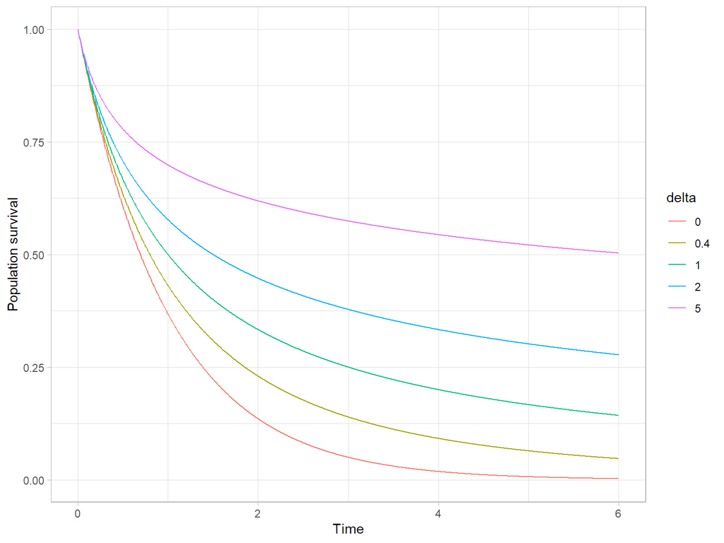

```r
expand.grid(t = seq(0,6,length=1001),
            delta = c(0, 0.4,1,2,5)) %>%
    mutate(alpha = 1,
           A = alpha*t,
           S = ifelse(delta==0, exp(-A), (1+delta*A)^(-1/delta)),
           delta=factor(delta)) %>%
    ggplot(aes(x=t, y=S, col=delta)) + geom_line() +
    ylim(0,1) + xlab("Time") +
    ylab("Population survival") + theme_light()
```

# Power variance function frailty

- As a general frailty family, the power variance function has a Laplace transform

$$\begin{align*}
\mathcal{L}(c;\rho,\nu,m) &= \exp\left(-\rho\left(1-\left(\frac{\nu}{\nu+c}\right)^m \right)\right)
\end{align*}$$

- The expectation is $E(Z)=\rho m / \nu$ and the variance is

$$\begin{align*}
\text{Var}(Z)=\frac{\rho m (m+1)}{\nu^2}
\end{align*}$$

# Power variance function frailty

- Population survival is represented by

$$\begin{align*}
S(t) &= \exp\left(-\rho\left(1-\left(\frac{\nu}{\nu+A(t)}\right)^m \right)\right)
\end{align*}$$

- The population hazard rate is represented by

$$\begin{align*}
\mu(t) &= \frac{\rho m}{\nu}\frac{\alpha(t)}{\left(1+A(t)/\nu\right)^{m+1}}
\end{align*}$$

- Assume that the basic hazard rates are $\alpha(t)$ for group 1 and $r\alpha(t)$ for group 2. The population hazard ratio is represented by

$$\begin{align*}
\frac{\mu_2(t)}{\mu_1(t)} &= r \left( \frac{\nu+A(t)}{\nu+r A(t)} \right)^{m+1}
\end{align*}$$

# Power variance function family: specific frailty distributions

For

$$\begin{align*}
\mathcal{L}(c;\rho,\nu,m) &= \exp\left(-\rho\left(1-\left(\frac{\nu}{\nu+c}\right)^m \right)\right)
\end{align*}$$

| Distribution | Properties |
| --- | --- |
| Gamma | $\rho\rightarrow\infty,\ m\rightarrow 0,\ \rho m\rightarrow\eta$ |
| Compound Poisson | $m>0,\ \rho>0$. Atom at 0 with probability $\exp(-\rho)$ |
| Hougaard | $-1<m<0,\ \rho<0$ |
| Inverse Gaussian | $m=-1/2,\ \rho<0$ |
| Stable | $-1<m<0,\ \nu\rightarrow 0,\ \rho\rightarrow -\infty,\ -\nu^m\rho\rightarrow a$ |
| Poisson | $m\rightarrow\infty,\ \nu\rightarrow\infty,\ m/\nu\rightarrow 1$. Discrete? |
| Normal | $\rho\rightarrow\pm\infty,\ \nu\rightarrow\infty,\ \rho/\nu\rightarrow a$ |

# Power variance function

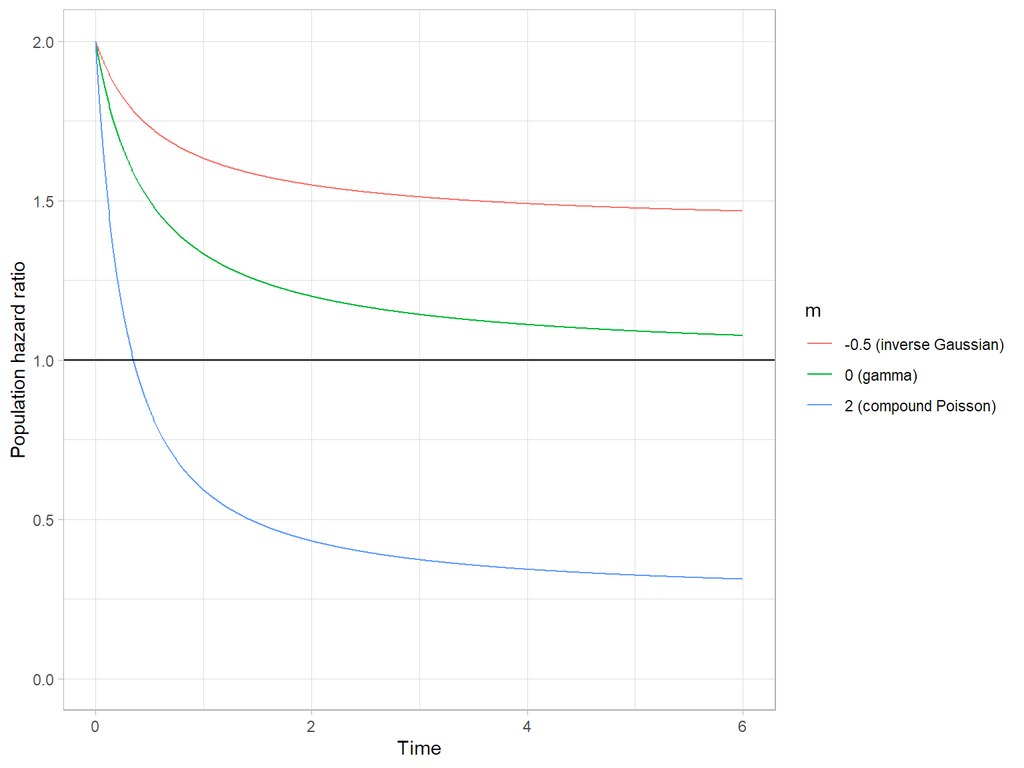

```r
expand.grid(t = seq(0,6,length=1001),
            m = c(-0.5, 0, 2)) %>%
    mutate(r=2, nu=1, alpha = 1,
           A = alpha*t,
           hr = r*((nu+A)/(nu+r*A))^(m+1),
           m=factor(ifelse(m==-0.5,"-0.5 (inverse Gaussian)",
                    ifelse(m==0,"0 (gamma)","2 (compound Poisson)")))) %>%
    ggplot(aes(x=t, y=hr, col=m)) + geom_line() +
    ylim(0,2) + xlab("Time") +
    ylab("Population hazard ratio") + theme_light() +
    geom_hline(yintercept=1)
```

# Positive stable frailty

- Consider also the positive frailty distribution, which has a Laplace transform:

$$\begin{align*}
\mathcal{L}(c;k,a) &= \exp(-ac^k)
\end{align*}$$

- The parameter $k$ takes values between 0 and 1. It is common to let $a=1$. The density is given by an infinite sum, and the mean and the variance are both undefined.
- The population hazard rate is:

$$\begin{align*}
\mu(t) &= -\alpha(t)\frac{\mathcal{L}'(c=A(t);k,a=1)}{\mathcal{L}(A(t);k,a=1)} = \alpha(t)k A(t)^{k-1}
\end{align*}$$

- The population hazard ratio is

$$\begin{align*}
\frac{\mu_2(t)}{\mu_1(t)} &= r^k
\end{align*}$$

which is constant with respect to time.

# Positive stable frailty $(a=1)$: population hazard rate $(\alpha(t)=1)$

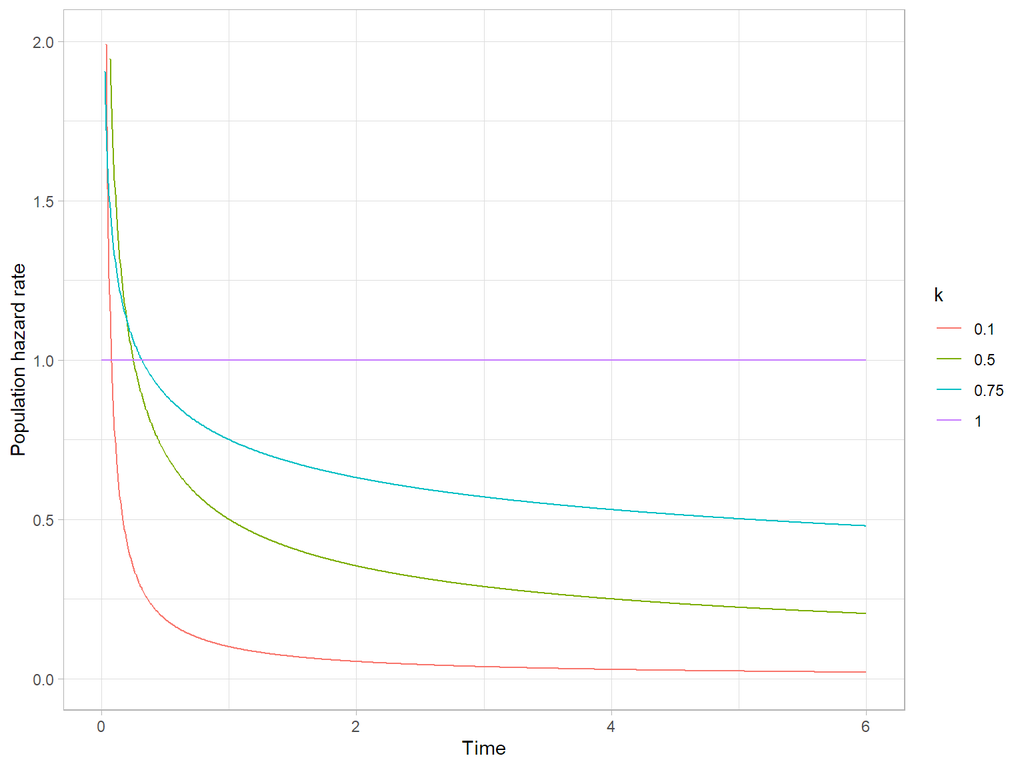

```r
expand.grid(t = seq(0,6,length=1001),
            k = c(0.1,0.5,0.75,1)) %>%
    mutate(alpha = 1,
           A = alpha*t,
           mu = alpha*A^(k-1)*k,
           k=factor(k)) %>%
    ggplot(aes(x=t, y=mu, col=k)) + geom_line() +
    ylim(0,2) + xlab("Time") +
    ylab("Population hazard rate") + theme_light()
```

# Positive stable frailty $(a=1)$: population survival $(\alpha(t)=1)$

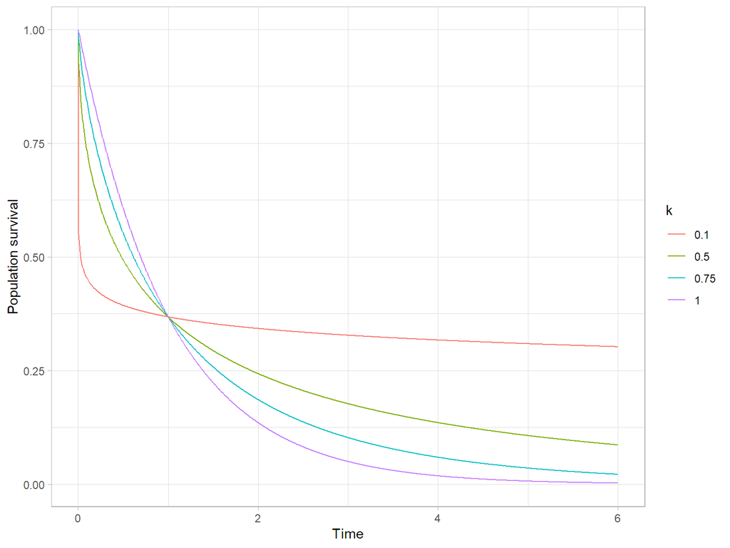

```r
expand.grid(t = seq(0,6,length=1001),
            k = c(0.1,0.5,0.75,1)) %>%
    mutate(alpha = 1,
           A = alpha*t,
           S = exp(-A^k),
           k=factor(k)) %>%
    ggplot(aes(x=t, y=S, col=k)) + geom_line() +
    ylim(0,1) + xlab("Time") +
    ylab("Population survival") + theme_light()
```

# Positive stable frailty $(a=1)$: population hazard ratio $(\alpha_0(t)=1, \alpha_1(t)=2)$

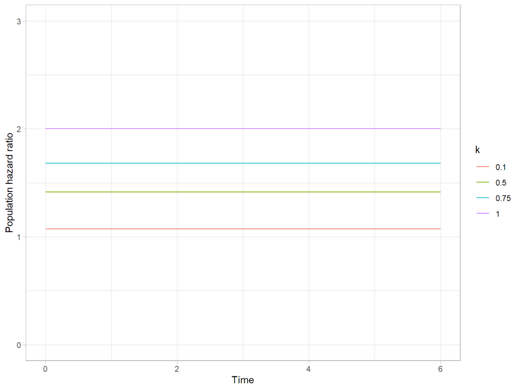

```r
expand.grid(t = seq(0,6,length=1001),
            k = c(0.1,0.5,0.75,1)) %>%
    mutate(alpha0 = 1,
           alpha1 = 2,
           A0 = alpha0*t,
           A1 = alpha1*t,
           hr = alpha1*A1^(k-1)*k/(alpha0*A0^(k-1)*k),
           k=factor(k)) %>%
    ggplot(aes(x=t, y=hr, col=k)) + geom_line() +
    ylim(0,3) + xlab("Time") +
    ylab("Population hazard ratio") + theme_light()
```

# Frailty and estimation: Identifiability

- When there is at most one event for each individual, the models will usually not be identifiable.
- As an exception, it is possible to hypothesise a parametric model class (e.g. Weibull) for $\alpha(t)$ and then fit a frailty model to univariate outcomes (see § 6.9). This is making strong assumptions.
- We will later see that most applications of frailty models use grouped data that are either clustered or for recurrent events.

# Frailties, random effects and unmeasured covariates

- We can interpret a frailty as being a random effect on the log hazards scale:

$$\begin{align*}
\log(\alpha(t|Z)) &= \log(\alpha(t)) + \log(Z)
\end{align*}$$

- By Jensen's inequality and noting that $\log(\cdot)$ is concave, we have that $\log(E(Z))\geq E(\log(Z))$. If $E(Z)=1$, then $E(\log(Z))\leq 0$. Conversely, if $E(\log(Z))=0$ then $E(Z)\geq 1$.
- As a specific case, if we have a log-normal frailty $Z$ with a normal random effect, such that $U=\log(Z)$ with $E(U)=0$ and $\text{var}(U)=\sigma^2$, then $E(Z)=E(\exp(U))=\exp(\sigma^2/2)\geq 1$.
- For an unmeasured covariate $X_k$ with parameter $\beta_k$, we can consider $X_k\beta_k$ as a random effect with a suitable expectation – that is, we can integrate for the unmeasured covariate.

# Collapsibility

- Informally, an association measure is collapsible if:

> The adjusted and unadjusted association measures are the same when control is made for factors $Z$ that are not associated with the exposures, and hence do not confound the exposure-outcome association (Martinussen and Vansteelandt 2013).
- Consider an event time $T$ with a binary exposure $X$ and a covariate $Z$. For a regression model, consider a linear predictor $\eta(t|X=x, Z=z)$. We then define a marginal association

$$\begin{align*}
\mathcal{T}_m(t) &= \eta(t|x=1) - \eta(t|x=0)
\end{align*}$$

and a marginal exposure effect (causal effect)

$$\begin{align*}
\mathcal{T}(t) &= \eta(t|\hat{x}=1) - \eta(t|\hat{x}=0)
\end{align*}$$

where $\eta(t|\hat{x})$ denotes the linear predictor that would be realized at time $t$ if $X$ were uniformly set to $x$ in the population.

- We assume that the covariate set $Z$ is sufficient to adjust for confounding, so that $\eta(t|\hat{x}=x,Z)=\eta(t|X=x,Z)$. We can now define the conditional association

$$\begin{align*}
\mathcal{T}_c(t) &= \eta(t|x=1,Z) - \eta(t|x=0,Z)
\end{align*}$$

- If $\mathcal{T}_c(t) \neq \mathcal{T}(t)$, such that there is a difference between the sub-group effects and population-averaged effect (which is typical for nonlinear association measures), then we have non-collapsibility.

# Aalen's additive hazards model

- Suppose that we have Aalen's additive hazards model

$$\begin{align*}
\alpha(t|x,z) &= \beta_0(t) + \beta_X(t)x + \beta_Z(t)z
\end{align*}$$

where $\beta(t)=[\beta_0(t),\beta_X(t),\beta_Z(t)]^T$ is a locally integrable function. Let $B_k(t)=\int_0^t \beta_k(s) ds$. The marginal (unadjusted) survival function is

$$\begin{align*}
S(t|X=x) &= E_Z(\exp(-(B_0(t) + B_X(t)x + B_Z(t)Z))|X=x) \\
&= \exp(-(B_0(t) + B_X(t)x)) E_Z(e^{-B_Z(t)Z}|X=x)
\end{align*}$$

- The marginal (unadjusted) hazard function is given by

$$\begin{align*}
\alpha(t|X=x) &= \frac{d}{dt} \left(-\log(S(t|X=x))\right) \\
&= \beta_0(t) + \beta_X(t)x + \beta_Z(t)\frac{E(Z e^{-B_Z(t)Z}|X=x)}{E(e^{-B_Z(t)Z}|X=x)}
\end{align*}$$

# Aalen's additive hazards model

- In contrast, the causal hazard function is

$$\begin{align*}
\alpha(t|\hat{x}=x) &= \tilde\beta_0(t) + \beta_X(t)x
\end{align*}$$

where $\tilde\beta_0(t)=\beta_0(t)+\beta_Z(t)\frac{E(Z e^{-B_Z(t)Z})}{E(e^{-B_Z(t)Z})}$.

- It is thus seen that the additive hazards structure is preserved and that the marginal exposure effect (using $\eta=\alpha$) is given by

$$\begin{align*}
\mathcal{T}(t) &= \alpha(t|\hat{x}=1) - \alpha(t|\hat{x}=0) = \beta_X(t)
\end{align*}$$

- This is also the conditional exposure effect, demonstrating that the model is collapsible.

# Proportional hazards model

- If we instead assume a proportional hazards model

$$\begin{align*}
\alpha(t|x,z) &= \alpha_0(t)e^{\beta_Xx + \beta_Zz}
\end{align*}$$

where $\alpha_0(t)$ is a locally integrable baseline hazard function. Then the marginal survival function is given by

$$\begin{align*}
S(t|X=x) &= E_Z(\exp(-A_0(t)e^{\beta_Xx + \beta_Zz})|X=x)
\end{align*}$$

and the marginal hazard function is given by

$$\begin{align*}
\alpha(t|x) &= \frac{d}{dt} \left(-\log(S(t|X=x))\right) \\
&= \alpha_0(t)e^{\beta_Xx}\frac{E_Z(e^{\beta_ZZ}e^{-A_0(t)\exp(\beta_Xx+\beta_ZZ)}|X=x)}{E_Z(e^{-A_0(t)\exp(\beta_Xx+\beta_ZZ)}|X=x)}
\end{align*}$$

# Proportional hazards model

- The causal hazard function is

$$\begin{align*}
\alpha(t|\hat{x}=x) &= \alpha_0(t)e^{\beta_Xx}\frac{E_Z(e^{\beta_ZZ}e^{-A_0(t)\exp(\beta_Xx+\beta_ZZ)})}{E_Z(e^{-A_0(t)\exp(\beta_Xx+\beta_ZZ)})}
\end{align*}$$

- If we consider the linear predictor for log hazards (such that $\eta=\log\alpha$), then

$$\begin{align*}
\mathcal{T}(t) &= \log(\alpha(t|\hat{x}=1)) - \log(\alpha(t|\hat{x}=0)) \\
&= \beta_X + \log\left(
\frac{E_Z(e^{\beta_ZZ}e^{-A_0(t)\exp(\beta_X+\beta_ZZ)})}{E_Z(e^{-A_0(t)\exp(\beta_X+\beta_ZZ)})} /
\frac{E_Z(e^{\beta_ZZ}e^{-A_0(t)\exp(\beta_ZZ)})}{E_Z(e^{-A_0(t)\exp(\beta_ZZ)})}
\right) \\
&\neq \mathcal{T}_c(t)
\end{align*}$$

# Accelerated failure time (AFT) model

- For an accelerated failure time model with covariates $X$ and $Z$:

$$\begin{align*}
\log(T) &= \mu+\boldsymbol\beta_X x + \beta_Z z + \epsilon
\end{align*}$$

where $\mu$ is an intercept and $\epsilon$ is an error (distribution) term. We assume that $Z$ and $\epsilon$ are stochastically independent. We then have that:

$$\begin{align*}
S(t|X=x,Z=z) &=S\left(t\,e^{-(\boldsymbol\beta_X x + \beta_Z z)}\right) \\
A(t|X=x,Z=z) &=A\left(t\,e^{-(\boldsymbol\beta_X x + \beta_Z z)}\right) \\
\alpha(t|X=x,Z=z) &=\alpha\left(t\,e^{-(\beta_X x + \beta_Z z)}\right)e^{-(\beta_X x + \beta_Z z)}
\end{align*}$$

# Accelerated failure time (AFT) model

- For the marginal distribution, a mathematical development using $E_Z(S(t|X,Z))$ is less helpful except in specific cases (e.g. constant hazards). For the marginal distribution,

$$\begin{align*}
E_Z(\log(T)|X) &= \mu+\beta_X X +\beta_Z E_Z(Z|X)) + \epsilon
\end{align*}$$

- If we let the linear predictor be $\eta=\log(T)$, then

$$\begin{align*}
\mathcal{T}(t) &= E_Z(\log(T)|\hat{x}=1) - E_Z(\log(T)|\hat{x}=0) \\
&= \beta_X = \mathcal{T}_c(t)
\end{align*}$$

which clearly indicates collapsibility.

# Points for discussion

1. Which other regression models are non-collapsible?
2. Should we stop using the Cox model?

# § 7: Multivariate frailty models

- We now consider grouped outcomes, where the groups can be defined in terms of
  1. Clusters, where similar individuals are grouped together
  2. Recurrent events, with the same individual possibly having multiple events of the same type
- For clustered outcomes, we can consider shared frailty models. Consider $m$ independent clusters with a cluster index $i$. Let the actual event time be $T_{ij}$ and let the observed times be $\tilde{T}_{ij}$ for cluster $i$ and individual $j$, with $n_i$ individuals in cluster $i$. ABG introduces these models using parametric models and later provides a limited development using counting processes.
- The basic rate $\alpha(t)$ is a fixed function and assumed to be the same for all $i$, but each cluster has a separate independent frailty $Z_i$ and that $\boldsymbol{Z}=(Z_i)$. All of the frailty variables are identically distributed. (Note: we ignore other covariates.)

# Multivariate frailty models

- Let $D_{ij}$ be binary variables that are 1 if the event time is uncensored and are 0 if censored. Let $D_{i\bullet}=\sum_j D_{ij}$, which is the number of events for cluster i.
- Assume that, conditional on $\boldsymbol{Z}=\boldsymbol{z}$, censoring is independent and noninformative on $\boldsymbol{z}$.
- Define the history for cluster $i$ as $H_i=(\tilde{T}_{ij}, D_{ij}, j=1,\ldots,n_i)$ and let $P(H_i)$ denote the joint distribution of these variables. Conditional with respect to $Z_i$, the event times are independent with intensity $Z_i\alpha(t)$ and their conditional likelihood is

$$\begin{align*}
P(H_i|Z_i) &= \prod_{j=1}^{n_i} \left(\left(Z_i\alpha(\tilde{T}_{ij})\right)^{D_{ij}}\exp(-Z_iA(\tilde{T}_{ij}))\right)
\end{align*}$$

# Multivariate frailty models

- The unconditional likelihood follows by taking the expectation with respect to frailty variable $Z$:

$$\begin{align*}
P(H_i) &= \prod_{j=1}^{n_i} \left(\alpha(\tilde{T}_{ij})^{D_{ij}}\right)
E_{Z_i}\left(Z_i^{D_{i\bullet}}\exp(-Z_i V_i)\right)
\end{align*}$$

where $V_i=\sum_j A(\tilde{T}_{ij})$.

- Applying the fact that the $r\text{th}$ derivative of a Laplace transform is $\mathcal{L}^{(r)}(c)=(-1)^rE(Z^r\exp(-cZ))$, we can now write

$$\begin{align*}
P(H_i) &= \prod_{j=1}^{n_i} \left(\alpha(\tilde{T}_{ij})^{D_{ij}}\right)
(-1)^{D_{i\bullet}}\mathcal{L}^{(D_{i\bullet})}(V_i)
\end{align*}$$

# Multivariate frailty models

- The total log-likelihood for the $m$ clusters is then

$$\begin{align*}
\log L &= \sum_{i=1}^m\left( \sum_{j=1}^{n_i} D_{ij}\log\left(\alpha(\tilde{T}_{ij})\right) +
\log\left((-1)^{D_{i\bullet}}\mathcal{L}^{(D_{i\bullet})}(V_i)\right) \right)
\end{align*}$$

- Estimation comes from maximising over a set of parameters, with covariance estimation by inversion of the negative Hessian.
- Hypothesis testing for the variance parameters may be at the boundary of the parameter space, which may require a mixture of distributions for the test statistic (e.g. a mixture of $\chi_0^2$ and $\chi_1^2$).
- Standard counting process tools can be used for proving the properties of the estimators.

# Multivariate frailty models - Gamma frailty

- As described earlier, the gamma frailty has a Laplace transform

$$\begin{align*}
\mathcal{L}(c;\nu,\eta) &= \left(\frac{\nu}{\nu+c}\right)^\eta
\end{align*}$$

- With mean 1 and a re-parameterisation for $\nu=\eta=\delta^{-1}$

$$\begin{align*}
\mathcal{L}(c) &= \mathcal{L}(c;\delta^{-1},\delta^{-1}) = (1+\delta c)^{-1/\delta}
\end{align*}$$

- The $s\text{th}$ derivative of this Laplace function is

$$\begin{align*}
\mathcal{L}^{(s)}(c) = \delta^s(-a)^s(1+\delta c)^{-1/\delta-s} \prod_{q=1}^s(1/\delta+q-1)
\end{align*}$$

# Multivariate frailty models - implementations

- For R, most frailty packages includes gamma and log-normal frailties. Extensions include:
  - `parfm`, which includes gamma, positive stable and inverse Gaussian frailties for simple parametric models (e.g. exponential, Weibull, gamma, log-normal AFTs).
  - `frailtySurv`, which includes gamma, positive stable, inverse Gaussian, log normal and power variance function frailties for semi-parametric models.
- For SAS, `proc phreg` includes gamma and log-normal frailties for semi-parametric models.
- For Stata:
  - `streg` includes gamma and inverse Gaussian frailties for simple parametric models.
  - `merlin` includes normal and t random effects for parametric functions.

# Power variance function: identifiability constraints

- For identifiability when fitting a shared frailty model, we are typically restricted to fitting one parameter, whereas the base PVF distribution has two parameters (after restricting for $E(Z)=1$, so that $\rho m = \nu$).
- One common approach is to fix $\nu=1$, so that $\rho =m^{-1}$ and

$$\begin{align*}
\mathcal{L}(c) &= \exp\left(-(1-(1+c)^{-m})/m\right)
\end{align*}$$

where $\text{Var}(Z)=m+1$.

- An alternative approach is to fix $m$ and then estimate $\nu$ (where $\rho=\nu/m$). Then $\text{Var}(Z)=(m+1)/ \nu$.

# Power variance function: identifiability constraints

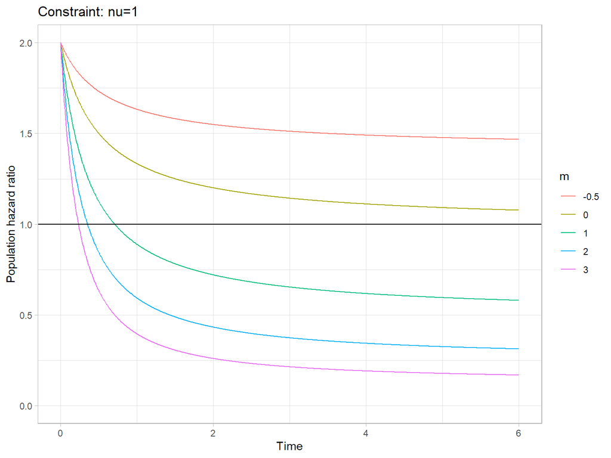

```r
expand.grid(t = seq(0,6,length=1001),
            m = c(-0.5, 0, 1, 2, 3)) %>%
    mutate(r=2, nu=1, alpha = 1,
           A = alpha*t,
           hr = r*((nu+A)/(nu+r*A))^(m+1),
           m = factor(m)) %>%
    ggplot(aes(x=t, y=hr, col=m)) + geom_line() +
    ylim(0,2) + xlab("Time") +
    ggtitle("Constraint: nu=1") +
    ylab("Population hazard ratio") + theme_light() +
    geom_hline(yintercept=1)
```

# Power variance function: identifiability constraints

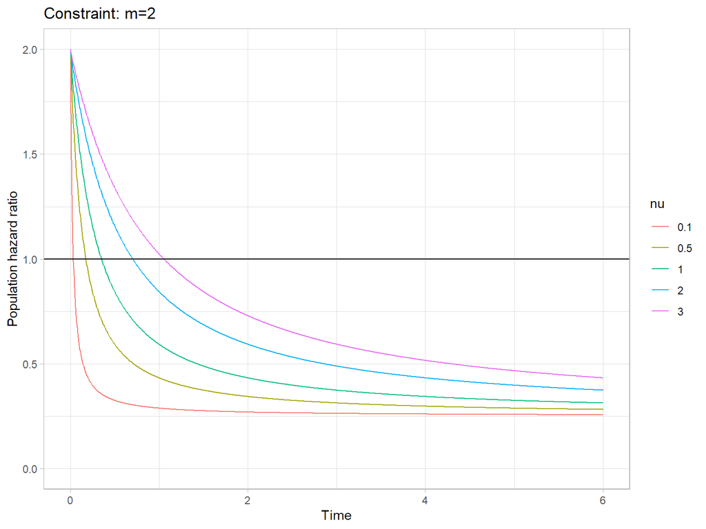

```r
expand.grid(t = seq(0,6,length=1001),
            nu = c(0.1, 0.5, 1, 2, 3)) %>%
    mutate(r=2, m=2, alpha = 1,
           A = alpha*t,
           hr = r*((nu+A)/(nu+r*A))^(m+1),
           nu = factor(nu)) %>%
    ggplot(aes(x=t, y=hr, col=nu)) + geom_line() +
    ylim(0,2) + xlab("Time") +
    ggtitle("Constraint: m=2") +
    ylab("Population hazard ratio") + theme_light() +
    geom_hline(yintercept=1)
```

# Regularity conditions for Weibull regression

Following ABGK (Example VI.1.1.11, pages 428–429):

- For $\alpha(t;\boldsymbol\theta)$, let the true parameter be represented by $\boldsymbol\theta_0$.
- Show that there exists a neighbourhood $\boldsymbol\Theta_0$ of $\boldsymbol\theta_0$ such that the derivatives of $\alpha(t;\boldsymbol\theta)$ of the first, second and third order with respect to $\boldsymbol\theta$ exist and are continuous in $\boldsymbol\theta$ for $\boldsymbol\theta \in \boldsymbol\Theta_0$.
- As a specific example, consider a Weibull regression model with $\alpha(t;\boldsymbol\theta)=\exp(\beta_0+\beta_1\log(t))$, where $\beta_1>-1$. If $\beta_1<0$, then as $t\downarrow 0$, then $\alpha(t;\boldsymbol\theta)\rightarrow\infty$. For the derivatives:

$$\begin{align*}
\frac{\partial^{(m+n)}\alpha(t;\boldsymbol\theta)}{\partial\beta_0^m \partial\beta_1^n} &= \exp(\beta_0+\beta_1\log(t))\log(t)^n
\end{align*}$$

# Regularity conditions for Weibull regression

And the partial derivatives of $\log(\alpha(\cdot))$ are

$$\begin{align*}
\frac{\partial\log(\alpha(t;\boldsymbol\theta))}{\partial\beta_0} &= 1 \\
\frac{\partial\log(\alpha(t;\boldsymbol\theta))}{\partial\beta_1} &= \log(t) \\
\frac{\partial^{(m+n)}\log(\alpha(t;\boldsymbol\theta))}{\partial\beta_0^m \partial\beta_1^n} &= 0,\quad\forall\ (m+n)>1
\end{align*}$$

# Regularity conditions for Weibull regression

- Moreover, show that $\int_0^x \alpha(t;\boldsymbol\theta)dt$ for any finite $x$ may be differentiated three times with respect to $\boldsymbol\theta\in\boldsymbol\Theta_0$ by interchanging the order of integration and differentiation.
- For the example,

$$\begin{align*}
\int_0^x \alpha(t;\boldsymbol\theta)dt &= \frac{x\,e^{\beta_{1}\,\log x+\beta_{0}}}{\beta_{1}+1}
= x\frac{\alpha(x;\boldsymbol\theta)}{\beta_{1}+1}
\end{align*}$$

- This expression can be differentiated with respect to $\boldsymbol\theta$ at least three times.
- This satisfies part A of Condition VI.1.1 in ABGK.

# Regularity conditions for Weibull regression

For boundedness and integrability conditions for parts B–E, first show that

$$\begin{align*}
\int_0^\infty \left(\frac{\partial}{\partial \theta_j}\log\alpha(t;\boldsymbol\theta_0)\right)^2\alpha(t;\boldsymbol\theta_0) S(t;\boldsymbol\theta_0) dt &< \infty \\
\int_0^\infty \left(\frac{\partial^2}{\partial \theta_j \partial\theta_l}\log\alpha(t;\boldsymbol\theta_0)\right)^2\alpha(t;\boldsymbol\theta_0) S(t;\boldsymbol\theta_0) dt &< \infty
\end{align*}$$

For the example:

- $\frac{\partial}{\partial \beta_0}\log\alpha(t;\boldsymbol\theta_0)=1$, so that the left hand side (LHS) of the first inequality equals 1.
- $\frac{\partial}{\partial \beta_1}\log\alpha(t;\boldsymbol\theta_0)=\log(t)$, so that the LHS of the first inequality is $\int_0^\infty \log(t)^2e^{\beta_0+\beta_1\log(t)-(e^{\beta_0+(\beta_1+1)\log(t)})/(\beta_1+1)} dt$. Is this bounded?
- $\frac{\partial^2}{\partial \theta_j \partial\theta_l}\log\alpha(t;\boldsymbol\theta_0)=0$, so that the second inequality is trivially satisfied.

# Regularity conditions for Weibull regression

$$\begin{align}
\text{sup}_{\boldsymbol\theta\in\boldsymbol\Theta_o}\left| \frac{\partial^3}{\partial \theta_j \partial \theta_l \partial \theta_m} \alpha(t;\boldsymbol\theta)\right| &\leq \gamma(t) & (1) \\
\text{sup}_{\boldsymbol\theta\in\boldsymbol\Theta_o}\left| \frac{\partial^3}{\partial \theta_j \partial \theta_l \partial \theta_m} \log\alpha(t;\boldsymbol\theta)\right| &\leq \rho(t) & (2)
\end{align}$$

Furthermore, show whether there exist functions $\gamma$ and $\rho$ such that for all $t\in[0,\infty]$ and

$$\begin{align}
\int_0^\infty \gamma(t)S(t;\boldsymbol\theta)dt &< \infty & (3) \\
\int_0^\infty \rho(t)\alpha(t;\boldsymbol\theta)S(t;\boldsymbol\theta)dt &< \infty & (4)
\end{align}$$

- Inequality (2) is trivially satisfied.

# Regularity conditions for Weibull regression

For inequality (1):

- $\frac{\partial^3}{\partial \beta_0^3} \alpha(t;\boldsymbol\theta) = \alpha(t;\boldsymbol\theta)$. If $\gamma(t)=\alpha(t;\boldsymbol\theta)$ then the LHS of inequality () is 1.
- $\frac{\partial^3}{\partial \beta_0^m \partial\beta_0^n} \alpha(t;\boldsymbol\theta) = \alpha(t;\boldsymbol\theta)\log(t)^n$. Let $\gamma(t)=|\alpha(t;\boldsymbol\theta)\log(t)^n|$ for $n\in\{1,2,3\}$. Does this satisfy inequality (3)?